# SS21 STT 180 Homework 2

Derien W

Feb 27-March 13, 2021

**General Instructions:**

- This is an individual assignment. You may consult with others as you work on the assignment, but each student should write up a separate set of solutions.
- Rather than creating a new Rmd file, just add your solutions to the supplied Rmd file. Submit **both** the Rmd file and the resulting HTML/PDF file to D2L.
- Except for questions, or parts of questions, that ask for your commentary, use R in a code chunk to answer the questions.
- The code chunk option `echo = TRUE` is specified in the setup code chunk at the beginning of the document. Please do not override this in your code chunks.
- A solution will lose points if the Rmd file does not compile. If one of your code chunks is causing your Rmd file to not compile, you can use the `eval = FALSE` option. Another possibility is to use the `error = TRUE` option in the code chunk.
- This Homework is due on **Saturday, March 13, 2021 on or before 11 pm.**
- Kindly submit **both** the .rmd and the HTML/PDF output files. If you submit the output in html format, zip the files while submitting.

**Setting up:**

Load `tidyverse`, which includes `dplyr`, `ggplot2`, `tidyr`, and other packages, and the load `knitr.

```r
library(tidyverse)
library(knitr)
```

Homework 2 has two sections. In Section 1 you will use data visualization and write function to analyze a dataset.For Section 2 you will read an article, explore the data, validate the claims and come to own conclusions.

# Section 1

For the first section of this homework will use the same birth dataset you used for Homework 1. Please use the `BirthDataWithRegionColors.csv` file for this HW. The dataset contains information about births in the United States. The full data set is from the Centers for Disease Control. The data for this homework assignment is a “small” sample (chosen at random) of slightly over one million records from the full data set. The data for this homework assignment also only contain a subset of the variables in the full data set.

## Introduction

Read in the data and convert the data frame to a tibble.

```r
birth_data <- read.csv("BirthDataWithRegionColors.csv", header = TRUE)
birth_data <- as_tibble(birth_data)
```

A glimpse of the data:

```r
glimpse(birth_data)
```

```
Rows: 1,048,575
Columns: 10
$ year          <int> 1969, 1969, 1969, 1969, 1969, 1969, 1969, 1969, 1969, 19…
$ month         <int> 2, 3, 5, 5, 5, 6, 8, 8, 11, 11, 11, 3, 3, 6, 7, 10, 3, 8…
$ state         <chr> "CA", "CA", "CA", "CA", "CA", "CA", "CA", "CA", "CA", "C…
$ is_male       <lgl> TRUE, FALSE, TRUE, FALSE, TRUE, TRUE, FALSE, FALSE, FALS…
$ weight_pounds <dbl> 6.999677, 6.876218, 7.187070, 7.749249, 7.374463, 9.6253…
$ mother_age    <int> 20, 25, 30, 17, 22, 26, 26, 19, 25, 26, 26, 31, 28, 24, …
$ child_race    <int> 1, 2, 1, 1, 4, 2, 1, 1, 1, 2, 1, 1, 1, 1, 1, 1, 1, 2, 2,…
$ plurality     <int> NA, NA, NA, NA, NA, NA, NA, NA, NA, NA, NA, NA, NA, NA, …
$ region        <chr> "West", "West", "West", "West", "West", "West", "West", …
$ state_color   <chr> "blue", "blue", "blue", "blue", "blue", "blue", "blue", …
```

The variables in the data set are:

| Variable | Description |
| --- | --- |
| `year` | the year of the birth |
| `month` | the month of the birth |
| `state` | the state where the birth occurred, including “DC” for Washington D.C. |
| `is_male` | which is `TRUE` if the child is male, `FALSE` otherwise |
| `weight_pounds` | the child’s birth weight in pounds |
| `mother_age` | the age of the mother |
| `child_race` | race of the child. |
| `plurality` | the number of children born as a result of the pregnancy, with 1 representing a single birth, 2 representing twins, etc. |

Combine `dplyr`with `ggplot2` to create graphical displays of the data. Use `filter`, `group_by`, and `summarize` build the required data frame.

### Question 1

Create a plot of mean age of mother versus year, which includes separate lines for each of the four regions of the country. (Don’t include data for which the region is missing.) The graphic should look like the following.

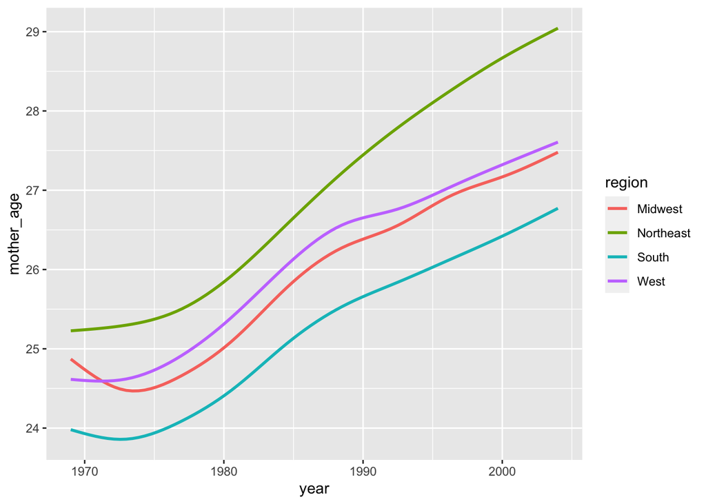

```r
birth_data %>%
  filter(region %in% c('West', 'South', 'Northeast', 'Midwest')) %>%
  ggplot(aes(x=year, y=mother_age, color=region)) +
  geom_smooth(se=F)
```

### Question 2

Create a graphic of mean age of mother versus year, which includes separate lines for each of the three values of `state_color`. (Don’t include data for which `state_color` is missing.) The graphic should look like the following. Notice that the colors are different from the default colors.

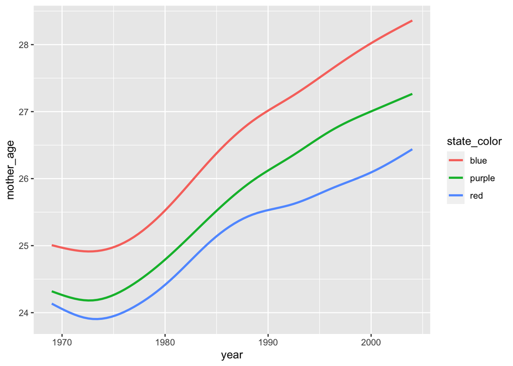

```r
birth_data %>%
  filter(state_color %in% c('blue', 'purple', 'red')) %>%
  ggplot(aes(x=year, y=mother_age, color=state_color)) +
  geom_smooth(se=F)
```

### Question 3

[figure not shown]

```r
 birth_data %>%
  filter(child_race %in% c('black', 'white')) %>%
  ggplot(aes(x=birth_data$year, y=birth_data$weight_pounds, color=birth_data$child_race)) +
  geom_smooth(se=F) +
  scale_color_discrete()
```

### Question 4

Create a graphic showing side-by-side boxplots of the age of the mother for the four regions. (Don’t include data for which `region` is missing.) The graphic should look like the following.

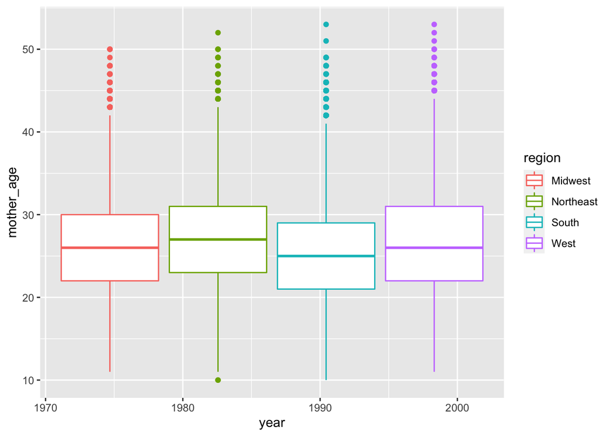

```r
birth_data %>%
  filter(region %in% c('West', 'South', 'Northeast', 'Midwest')) %>%
  ggplot(aes(x=year, y=mother_age, color=region)) +
  geom_boxplot()
```

### Question 5

Write a function called `quantitative_summary` which takes two inputs:  
`x`: A numeric vector  
`group`: A factor vector of the same length as x

and produces a **list** as output which contains the following elements:  
`missing`: The number of missing values in x  
`means`: The means of x for each level of groups.  
`sds`: The standard deviations of x for each level of groups  
`is.binary`: Set to FALSE for for this function

Here is an example of the function in action.

```r
quantitative_summary <- function(x,group) {
  list(missing = sum(is.na(x)),
       means = tapply(x, group,mean,na.rm = TRUE),
       sds = tapply(x, group, sd,na.rm = TRUE),
       p.value = (summary(aov(x ~ group, na.action = na.omit))[[1]][["Pr(>F)"]][1]),
       is.binary = apply(birth_data,2,function(x) { all(x %in% 0:1)}))
}
quantitative_summary(birth_data$weight_pounds, birth_data$is_male)
```

```
$missing
[1] 1583

$means
   FALSE     TRUE
7.178759 7.438649

$sds
   FALSE     TRUE
1.283197 1.353845

$p.value
[1] 0

$is.binary
         year         month         state       is_male weight_pounds
        FALSE         FALSE         FALSE         FALSE         FALSE
   mother_age    child_race     plurality        region   state_color
        FALSE         FALSE         FALSE         FALSE         FALSE
```

Hint:

- When computing the means and standard deviations, you need to exclude missing values using `na.rm`.

### Question 6

Write a function called `binary_summary` which takes two inputs:  
`x`: A vector containing the values 0 and 1 (possibly NA)  
`group`: A factor vector of the same length as x

and produces a **list** as output which contains the following elements:  
`missing`: The number of missing values in x  
`prop`: The proportion of 1s in x for each level of groups  
`is.binary`: Set to TRUE for for this function.

Here is an example of the function in action using plurality defined as a binary variable (single vs multiple births):

```r
# Function to calculate the proportion of 1s in x for each level of group
calculation <- function(x){

res <- x %>%
group_by(plurality, is_male) %>%
summarise(n = n()) %>%
mutate(freq = n / sum(n))

res<- res[c(2,4,6),]

birth_data <- subset(res, select = c(plurality, is_male))

res<-(birth_data)
row.names(res)<-c()

return(res)
}
binary_summary <- function(x,group) {
list(

missing = sum(is.na(x)),

prop = calculation(birth_data),
is.binary = TRUE
)
}
```

```r
binary_summary(birth_data$plurality, birth_data$is_male)
```

```
$missing
[1] 27869

$prop
# A tibble: 3 x 2
# Groups:   plurality [3]
  plurality is_male
      <int> <lgl>
1         1 TRUE
2         2 TRUE
3         3 TRUE

$is.binary
[1] TRUE
```

# Section 2

Flint is the second poorest city of its size in the United States and has spent six of the past 15 years in a state of financial emergency. One of the cost-cutting measures taken by emergency managers was to stop buying water, sourced from Lake Huron, from the Detroit Water and Sewerage Department. Instead, Flint would use the Flint River for its water supply while waiting for a new pipeline to Lake Huron to be opened. The move was expected to save roughly $5 million over a period of two years.

The Flint River supply was switched on in April 2014. Not long after, problems arose.Flint resident and mother of four LeeAnne Walters noticed that the water coming out of her taps was orange. More worryingly, her family’s hair was falling out, her preschool sons had broken out in rashes and one of them had stopped growing.

The orange colour was from iron, but the family’s symptoms pointed to a far more dangerous contaminant: lead. (Langkjaer - Bain 2017)

## Introduction

The data set consists of 271 homes sampled with three water lead contaminant values at designated time points. The lead content is in parts per billion (ppb). Additionally, some location data is given about each home.

- **id**: sample id number
- **zip**: zip code in Flint as to the water sample’s location
- **ward**: ward in Flint as to the water sample’s location
- **draw**: water sample at one of three time points
- **lead**: lead content in parts per billion

Before you get started, read *The murky tale of Flint’s deceptive water data* by Langkjaer - Bain (2017).

```r
flint_data <- read.csv("flint.csv", header = TRUE)
flint_data <- as_tibble(flint_data)
head(flint_data)
```

| id | zip | ward | draw | lead | flushing_time..in.sec. |
| --- | --- | --- | --- | --- | --- |
| 1 | 48504 | 6 | first | 0.344 | 0 |
| 2 | 48507 | 9 | first | 8.133 | 0 |
| 4 | 48504 | 1 | first | 1.111 | 0 |
| 5 | 48507 | 8 | first | 8.007 | 0 |
| 6 | 48505 | 3 | first | 1.951 | 0 |
| 7 | 48507 | 9 | first | 7.200 | 0 |

### Question 1

Select one passage that you found particularly striking (perhaps you strongly agreed or disagreed with it, perhaps it made you question an assumption or seemed unclear) in the article and write a 4-5 sentence paragraph commenting on it.

## In the sampling errors section on page 18 of the article, there was a claim that when 300 hundred water sampling kits were sent out, 271 of those came back positive for contaminants. That means that 90% of sample size did not have safe water to drink. This stood out to me because it seems kind of inhumane to actively test for something that will not actively get fixed, seeing as the problem with Flint still remains today. It makes you wonder if this is deliberate to try and weed out certain parts of the city or a harmful accident. I think that it’s safe to say which 10% of the sampling kits didn’t come back positive for contaminants. I do not want to explicitly say though.

### Question 2

How many unique zip codes are in the data set? How many unique wards are in the data set?

```r
unique(flint_data$zip)
```

```
[1] 48504 48507 48505 48503 48506 48529 48532 48502
```

```r
unique(flint_data$ward)
```

```
 [1] 6 9 1 8 3 5 2 7 4 0
```

```r
length(unique(flint_data$zip))
```

```
[1] 8
```

```r
length(unique(flint_data$ward))
```

```
[1] 10
```

Do the number of wards in the data set match how many wards Flint has? If not, suggest a way to handle this discrepancy. ## The city of Flint has 9 wards. A possible explanation is that one of the wards that is counted as unique, probably isn’t.

### Question 3

Which ward appears to have the worst water quality? Note that your answer should consider mean, median, and maximum lead levels. Your choice of ‘worst ward’ should include justification for why some of these statistics are more important to consider than others.

```r
summary(flint_data$lead[flint_data$ward == "1"])
```

```
   Min. 1st Qu.  Median    Mean 3rd Qu.    Max.
  0.031   0.400   1.171   2.584   2.975  23.850
```

```r
summary(flint_data$lead[flint_data$ward == "2"])
```

```
    Min.  1st Qu.   Median     Mean  3rd Qu.     Max.
   0.120    0.653    2.486   24.196    6.299 1051.000
```

```r
summary(flint_data$lead[flint_data$ward == "3"])
```

```
    Min.  1st Qu.   Median     Mean  3rd Qu.     Max.
  0.0350   0.4933   1.8740   6.7084   4.3898 118.4000
```

```r
summary(flint_data$lead[flint_data$ward == "4"])
```

```
   Min. 1st Qu.  Median    Mean 3rd Qu.    Max.
  0.094   0.393   0.896   3.884   2.745 138.800
```

```r
summary(flint_data$lead[flint_data$ward == "5"])
```

```
   Min. 1st Qu.  Median    Mean 3rd Qu.    Max.
  0.100   0.788   2.248   5.967   7.561  66.240
```

```r
summary(flint_data$lead[flint_data$ward == "6"])
```

```
    Min.  1st Qu.   Median     Mean  3rd Qu.     Max.
  0.1370   0.6052   2.1135  12.8995   6.1372 239.7000
```

```r
summary(flint_data$lead[flint_data$ward == "7"])
```

```
   Min. 1st Qu.  Median    Mean 3rd Qu.    Max.
  0.058   1.014   2.477   6.546   6.877 105.300
```

```r
summary(flint_data$lead[flint_data$ward == "8"])
```

```
   Min. 1st Qu.  Median    Mean 3rd Qu.    Max.
  0.231   1.169   3.100  10.532   6.588 158.000
```

```r
summary(flint_data$lead[flint_data$ward == "9"])
```

```
   Min. 1st Qu.  Median    Mean 3rd Qu.    Max.
  0.096   0.499   1.927   4.831   6.974  50.970
```

```r
## Looking at the data for the lead content in each ward, worst ward is #2 by far. The highest max and mean lead content.
```